# Fitting advanced occupancy models

It is reasonable that some sites are more likely to have otters than others.

To run this analysis successfully, it is recommended to take a larger sample size, such as between 20-30 sites per covariate. This may seem like a lot, but it is necessary due to the limited variation in the data (only non-detection (0) and detection (1) information is available) and the need for covariates to explain this variation. If the sample size is too small or there are too many covariates relative to the sample size, the model may not be able to accurately estimate the parameters and may produce incorrect results or NAs. If you do not have enough data to include certain model extensions, it is better to leave them out to avoid making an incorrect analysis. For this analysis, we will be using a larger data set called “otter2.csv” that includes 94 independent sites.

```r
#load data set
otter2 <- read.csv("otter2.csv", comment = "#", header = TRUE)
head(otter2)
```

```
##          y        x detection.1 detection.2 detection.3 detection.4 detection.5
## 1 264245.4 561647.0           0           0           0           0           0
## 2 258744.4 552143.5           0           0           1           0           0
## 3 217736.9 493622.0           1           0           0           1           0
## 4 253243.4 528134.7           0           0           0           0           0
## 5 326256.7 511128.4           0           0           0           0           0
## 6 292750.6 518131.0           0           0           0           0           0
##   detection.6 detection.7 detection.8 detection.9 detection.10 detection.11
## 1           0           0           0           0            0            0
## 2           0           0           0           0            0            0
## 3           1           0           0           0            1            0
## 4           0           0           0           0            0            0
## 5           0           0           0           0            0            0
## 6           0           0           1           0            0            0
##   detection.12 detection.13 detection.14 detection.15 detection.16 detection.17
```

[output cut: 104 more lines]

```r
dim(otter2)
```

```
## [1]  94 125
```

```r
#load R package
install.packages("unmarked")
library(unmarked)
#re-organise input data
umf <- unmarkedFrameOccu(
    y = otter2[, 3:62],
    siteCovs = data.frame(elevation = otter2$elevation,
                          forest = otter2$forest,
                          water = otter2$water),
    obsCovs = list(temp = otter2[, 66:125]))
summary(umf)
```

```
## unmarkedFrame Object
##
## 94 sites
## Maximum number of observations per site: 60
## Mean number of observations per site: 60
## Sites with at least one detection: 52
##
## Tabulation of y observations:
##    0    1
## 5165  475
##
## Site-level covariates:
##    elevation          forest         water
##  Min.   :  80.0   Min.   :13.0   Min.   : 5.000
##  1st Qu.: 385.0   1st Qu.:30.0   1st Qu.: 5.000
##  Median : 609.5   Median :34.0   Median : 5.000
##  Mean   : 630.1   Mean   :33.4   Mean   : 8.543
##  3rd Qu.: 838.0   3rd Qu.:39.0   3rd Qu.: 5.000
##  Max.   :1297.0   Max.   :46.0   Max.   :52.000
##
## Observation-level covariates:
##       temp
##  Min.   : 9.00
##  1st Qu.:23.75
##  Median :27.00
##  Mean   :27.10
##  3rd Qu.:30.00
##  Max.   :48.00
```

## Fitting occupancy models with covariate effects

If you have a large number of sampling sites, you can consider fitting occupancy models that include covariate effects. This example generates 15 additional models using every combination of site and observation covariates. This can be time-consuming, so it is recommended to carefully choose candidate model sets based on your knowledge of the species or system rather than using this approach.

So here are the models written in the unmarked notation.

```r
#constant detection and abundance
m1 <- occu(~1 ~1, data = umf)

#variations in detection (psi~1)
m2 <- occu(~temp ~1, data = umf)

#variations in occupancy (p~1)
m3 <- occu(~1 ~elevation, data = umf)
m4 <- occu(~1 ~forest, data = umf)
m5 <- occu(~1 ~water, data = umf)
m6 <- occu(~1 ~elevation+forest, data = umf)
m7 <- occu(~1 ~elevation+water, data = umf)
m8 <- occu(~1 ~forest+water, data = umf)
m9 <- occu(~1 ~elevation+forest+water, data = umf)

#variations in both detection and occupancy
m10 <- occu(~temp ~elevation, data = umf)
m11 <- occu(~temp ~forest, data = umf)
m12 <- occu(~temp ~water, data = umf)
m13 <- occu(~temp ~elevation+forest, data = umf)
m14 <- occu(~temp ~elevation+water, data = umf)
m15 <- occu(~temp ~forest+water, data = umf)
m16 <- occu(~temp ~elevation+forest+water, data = umf)
```

## Choosing ‘best’ model

To compare the list of models you have created, you can use the aictab() function from the AICcmodavg package to calculate the AIC. The output will be a table. A quick examination of the AIC scores will show that model m14 is considered the best for this data. Model m14 includes elevation and water as predictors of occupancy, and ambient temperature as a predictor for detection.

```r
library(AICcmodavg)
fit.list <- aictab(c(m1, m2, m3, m4, m5, m6, m7, m8, m9, m10, m11, m12, m13, m14, m15, m16))
fit.list
```

```
##
## Model selection based on AICc:
##
##       K    AICc Delta_AICc AICcWt Cum.Wt       LL
## Mod14 5 2734.01       0.00   0.31   0.31 -1361.66
## Mod16 6 2734.05       0.04   0.31   0.62 -1360.54
## Mod13 5 2734.30       0.29   0.27   0.89 -1361.81
## Mod10 4 2736.06       2.05   0.11   1.00 -1363.80
## Mod7  4 2750.14      16.12   0.00   1.00 -1370.84
## Mod9  5 2750.26      16.25   0.00   1.00 -1369.79
## Mod6  4 2750.67      16.65   0.00   1.00 -1371.11
## Mod3  3 2752.59      18.58   0.00   1.00 -1373.16
## Mod15 5 2764.81      30.80   0.00   1.00 -1377.07
## Mod12 4 2767.45      33.44   0.00   1.00 -1379.50
## Mod11 4 2771.05      37.04   0.00   1.00 -1381.30
## Mod2  3 2778.73      44.72   0.00   1.00 -1386.23
## Mod8  4 2781.23      47.22   0.00   1.00 -1386.39
## Mod5  3 2783.91      49.90   0.00   1.00 -1388.82
## Mod4  3 2787.51      53.50   0.00   1.00 -1390.62
## Mod1  2 2795.24      61.23   0.00   1.00 -1395.55
```

## Making predictions

### Single point

Using the best model, you can predict the occupancy of a sampling site based on its characteristics (e.g. elevation and water content) or the detection probability based on weather conditions. To predict a single data point, you can use the plogis() function, taking into account the covariate effects and the values of interest. For example, if you want to use model m14, which includes covariates, you would need to factor in these covariates in your calculation.

```r
#what is the occupancy of a sampling site situated at 1000m above sea level and
#covered by 25% water?
predict.occupancy <- plogis(m14@opt$par[1] +            #occupancy intercept
                            m14@opt$par[2]*1000 +       #elevation
                            m14@opt$par[3]*25)          #water content
predict.occupancy*100
```

```
## [1] 43.53411
```

```r
#what is the detection probability of a sampling site if sampling is done on 37
#degree weather?
predict.detection <- plogis(m14@opt$par[4] +            #detection intercept
                            m14@opt$par[5]*37)          #temperature
predict.detection*100
```

```
## [1] 21.02189
```

### 2D surface

In addition to creating plots, you can also create maps to visualize the predictions of occupancy. This can be especially useful if the model includes geographical covariates. Mapping the parameter estimates in environmental or geographical space can help you understand the relationships between the covariates and the model’s predictions. This can provide a powerful way to interpret the results of the model.

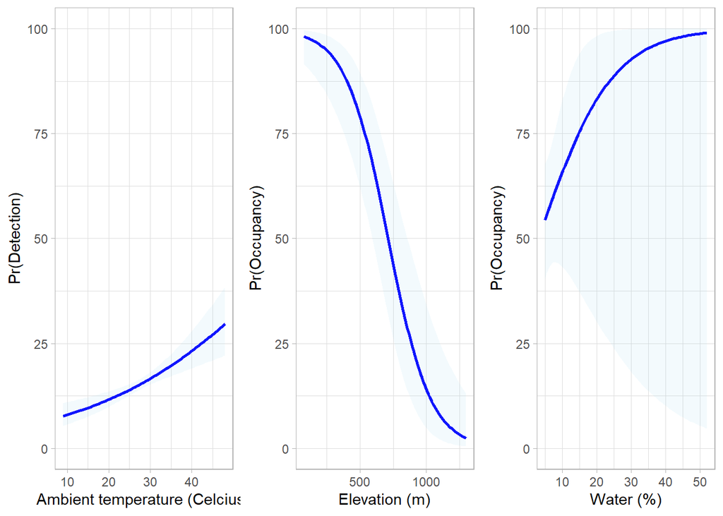

```r
##load graphics packages
library(ggplot2)
library(cowplot)

##predict occupancy across elevation range
#prepare new data
pred.e <- data.frame(
    elevation = seq(min(umf@siteCovs$elevation, na.rm = TRUE),      # min elevation
                    max(umf@siteCovs$elevation, na.rm = TRUE),      # max elevation
                    length = 100),                                  # number of points in range
    water = rep(mean(umf@siteCovs$water), length = 100))            # average water content
pred.elevation <- predict(
    m14,                        # model to predict from
    type = "state",             # sub model to predict from
    newdata = pred.e,           # new values to use for predictions
    append = TRUE)              # add new data to prediction data frame
#setup elevation plot
gpred.elevation <- ggplot() +
    geom_line(aes(x = pred.elevation$elevation, y = pred.elevation$Predicted*100), color = "blue", size = 1) +
    geom_ribbon(aes(x = pred.elevation$elevation, ymin = pred.elevation$lower*100,
                ymax = pred.elevation$upper*100), fill = "skyblue", alpha = 0.1) +
    ylab("Pr(Occupancy)") +
    xlab("Elevation (m)") +
    ylim(0, 100) +
    theme_light()

##predict occupancy across water content range
#prepare new data
pred.w <- data.frame(
    elevation = rep(mean(umf@siteCovs$elevation), length = 100),    # average elevation
    water = seq(min(umf@siteCovs$water, na.rm = TRUE),              # min water content
                max(umf@siteCovs$water, na.rm = TRUE),              # max water content
                length = 100))                                      # number of points in range
#predict occupancy with new data
pred.water <- predict(
    m14,                        # model to predict from
    type = "state",             # sub model to predict from
    newdata = pred.w,           # new values to use for predictions
    append = TRUE)              # add new data to prediction data frame
#setup water plot
gpred.water <- ggplot() +
    geom_line(aes(x = pred.water$water, y = pred.water$Predicted*100), color = "blue", size = 1) +
    geom_ribbon(aes(x = pred.water$water, ymin = pred.water$lower*100,
                ymax = pred.water$upper*100), fill = "skyblue", alpha = 0.1) +
    ylab("Pr(Occupancy)") +
    xlab("Water (%)") +
    ylim(0, 100) +
    theme_light()

##predict detection across temperature range
#prepare new data
pred.t <- data.frame(
    temp = seq(min(umf@obsCovs$temp, na.rm = TRUE), # min temperature
               max(umf@obsCovs$temp, na.rm = TRUE), # max temperature
               length = 100))                       # number of points in range
#predict detection with new data
pred.temp <- predict(
    m14,                        # model to predict from
    type = "det",               # sub model to predict from
    newdata = pred.t,           # new values to use for predictions
    append = TRUE)              # add newdata to prediction data frame
#setup temperature plot
gpred.temp <- ggplot() +
    geom_line(aes(x = pred.temp$temp, y = pred.temp$Predicted*100), color = "blue", size = 1) +
    geom_ribbon(aes(x = pred.temp$temp, ymin = pred.temp$lower*100, ymax = pred.temp$upper*100),
                fill = "skyblue", alpha = 0.1) +
    ylab("Pr(Detection)") +
    xlab("Ambient temperature (Celcius)") +
    ylim(0, 100) +
    theme_light()

#plot predictions side-by-side
plot_grid(gpred.temp, gpred.elevation, gpred.water, nrow = 1)
```

### 3D surface

You can also illustrate by mapping the predictions of occupancy. Projecting parameter estimates in environmental or geographical space is also a powerful way to understand what the model tells about covariate relationships.

```r
study_area <- read.csv("study_area.csv", comment = "#", header = TRUE)
head(study_area)
```

```
##          y        x elevation forest water
## 1 372765.2 484618.6       573     48     5
## 2 372265.1 484118.4       502     47     5
## 3 372265.1 484618.6       761     48     5
## 4 372265.1 499124.0       942     42     5
## 5 372265.1 499624.2       688     43     5
## 6 372265.1 500124.4       524     34     5
```

```r
dim(study_area)
```

```
## [1] 78233     5
```

```r
siteCovs.map <- data.frame(elevation = study_area$elevation,
                           water = study_area$water)
head(siteCovs.map)
```

```
##   elevation water
## 1       573     5
## 2       502     5
## 3       761     5
## 4       942     5
## 5       688     5
## 6       524     5
```

Just like before, you will need to use the function to estimate occupancy, standard errors, and confidence intervals for each site/pixel.

```r
predict.occupancy <- predict(
    m14,                            # model to predict from
    type = "state",                 # sub model to predict from
    newdata = siteCovs.map,         # new values to use for predictions
    append = TRUE)                  # add newdata to prediction data frame
#save predictions
save(predict.occupancy, file = "predict.occupancy.RData")
```

Setup elevation map

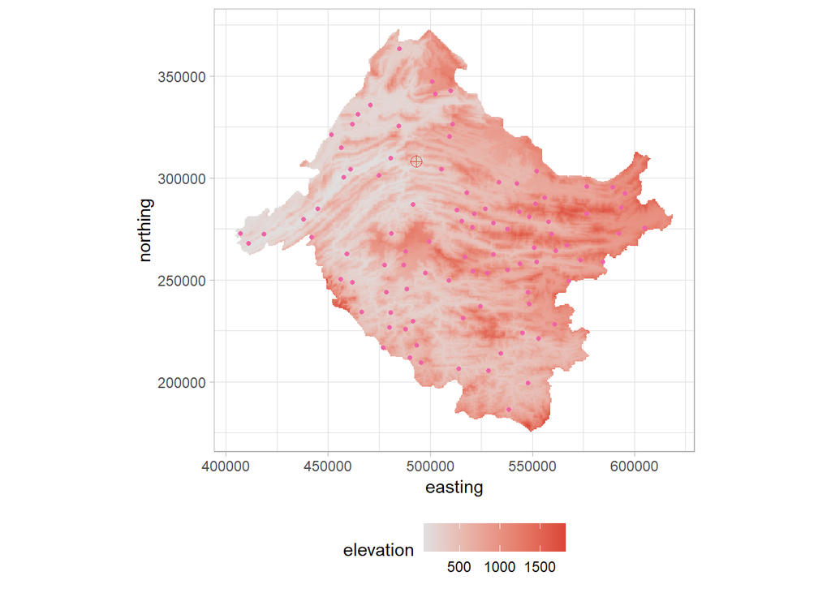

```r
elevation.map <- ggplot() +
    geom_tile(data = study_area, aes(x = x, y = y, fill = elevation)) +
        scale_fill_gradient(low = "grey88", high = "#DB4437") +
    xlab("easting") +
    ylab("northing") +
    coord_fixed() +
    theme_light() +
    theme(plot.title = element_text(hjust = 0.5)) +
    theme(legend.position = "bottom") +
    geom_point(aes(x = otter2$x, y = otter2$y), colour = "#F062A7", shape = 16, alpha = 1, size = 1) +
    geom_point(aes(x = 493092, y = 308119), colour = "#DB4437", shape = 10, size = 3)
elevation.map
```

Setup water map

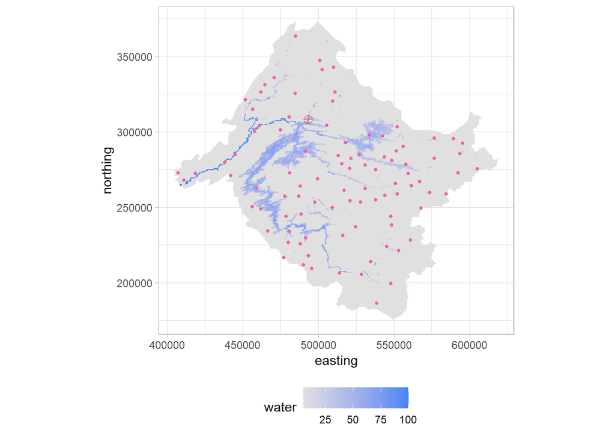

```r
water.map <- ggplot() +
    geom_tile(data = study_area, aes(x = x, y = y, fill = water)) +
        scale_fill_gradient(low = "grey88", high = "#4285F4") +
    xlab("easting") +
    ylab("northing") +
    coord_fixed() +
    theme_light() +
    theme(plot.title = element_text(hjust = 0.5)) +
    theme(legend.position = "bottom") +
    geom_point(aes(x = otter2$x, y = otter2$y), colour = "#F062A7", shape = 16, alpha = 1, size = 1) +
    geom_point(aes(x = 493092, y = 308119), colour = "#DB4437", shape = 10, size = 3)
water.map
```

Setup occupancy map

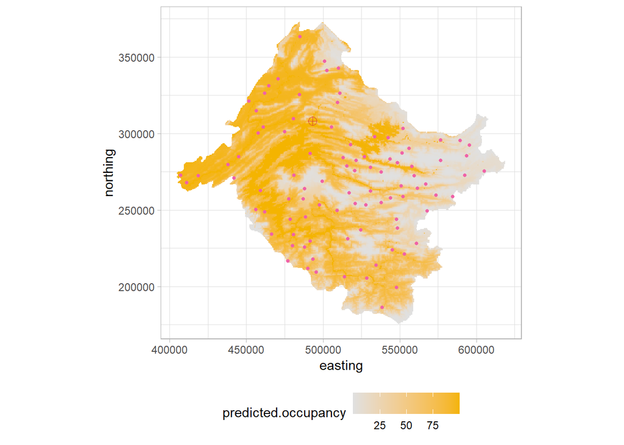

```r
#load prediction output
load("predict.occupancy.RData")
#copy predictions' Mean and SE into study area
study_area$predicted.occupancy <- predict.occupancy$Predicted*100
study_area$uncertainty <- predict.occupancy$SE*100

occupancy.predicted <- ggplot() +
    geom_tile(data = study_area, aes(x = x, y = y, fill = predicted.occupancy)) +
        scale_fill_gradient(low = "grey88", high = "#F4B400") +
    xlab("easting") +
    ylab("northing") +
    coord_fixed() +
    theme_light() +
    theme(plot.title = element_text(hjust = 0.5)) +
    theme(legend.position = "bottom") +
    geom_point(aes(x = otter2$x, y = otter2$y), colour = "#F062A7", shape = 16, alpha = 1, size = 1) +
    geom_point(aes(x = 493092, y = 308119), colour = "#DB4437", shape = 10, size = 3)
occupancy.predicted
```

Setup occupancy’s standard error (uncertainty) map

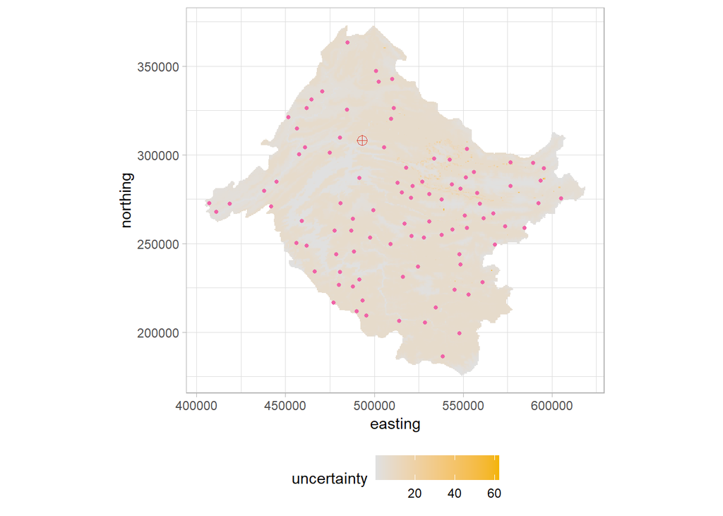

```r
occupancy.uncertainty <- ggplot() +
    geom_tile(data = study_area, aes(x = x, y = y, fill = uncertainty)) +
        scale_fill_gradient(low = "grey88", high = "#F4B400") +
    xlab("easting") +
    ylab("northing") +
    coord_fixed() +
    theme_light() +
    theme(plot.title = element_text(hjust = 0.5)) +
    theme(legend.position = "bottom") +
    geom_point(aes(x = otter2$x, y = otter2$y), colour = "#F062A7", shape = 16, alpha = 1, size = 1) +
    geom_point(aes(x = 493092, y = 308119), colour = "#DB4437", shape = 10, size = 3)
occupancy.uncertainty
```

The occupancy analysis framework is a reliable and flexible statistical method that can provide a more accurate understanding of where a species has been detected and how it uses its habitat. Using this framework, you can make predictions of species occupancy that can identify important corridors and habitat patches for conservation, and help agencies evaluate and optimize management strategies. This framework is useful for landscape-based wildlife monitoring, and although sampling for predictive mapping can be challenging, identifying the potential occurrence of important species can help improve our understanding of their spatial ecology and inform conservation and management plans.